# Tracer un cercle ou un carré sur la Terre

Kezhan SHI

02 Novembre 2015

# 1 Introduction

En lisant des articles sur internet l’autre jour, j’ai vu qu’une start-up dénommée [what3words](http://what3words.com) se développait rapidement en déployant une technique de géolocalisation. De prime abord, c’était assez farfelu : elle consiste tout simplement à donner trois mots, pour désigner un carré de 3m x 3m sur la surface de de la Terre. L’argument principal est que c’est un moyen beaucoup plus facile à retenir et à communiquer pour les hommes, que les coordonnées GPS avec plein de chiffres.

L’article parlait aussi de l’industrie géospatiale qui pourrait générer des millards d’euros d’ici quelques années. Du coup, je me suis repenché sur quelques techniques sur R :

- Géocoder une adresse quelconque sur la Terre
- Afficher les points sur un plan
- Compter les points à un endroit donné pour étudier leur répartition

Sur le dernier point, j’avais utilisé un simple maillage en fonction des latitude/longitude, pour étudier l’implantation géographique de certaines enseignes en France Et si on devait tracer des cercles ?

# 2 Eléments de base

Quelques éléments pour commencer :

- Comme la Terre est approximativement sphérique, on utilise des coordonnées angulaires (latitude/longitude) pour situer un point sur la surface.

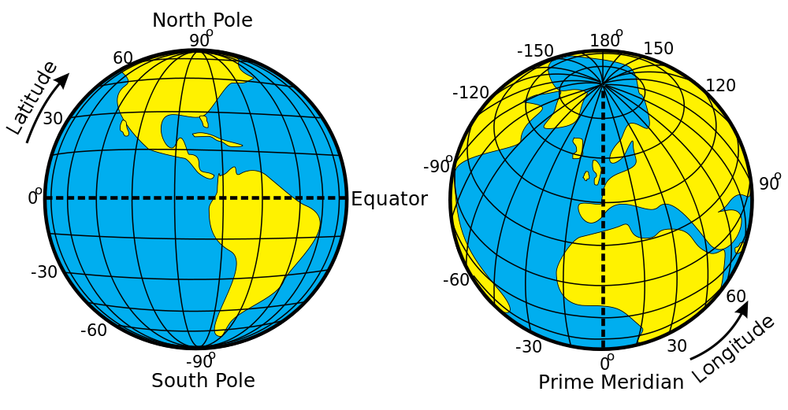

- Comme on aime bien travailler sur une surface plate, on fait alors des projections. Il y a plusieurs types de projection.

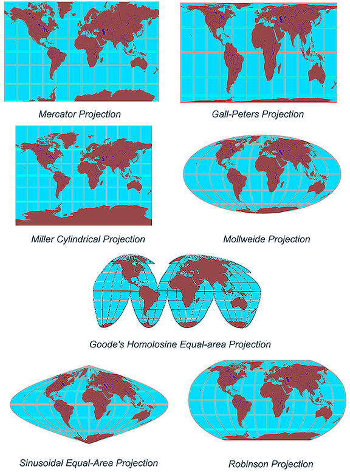

- La projection utilisée couramment est la projection Mercator. Google Maps ou OpenStreetMap utilisent cette projection (Plus précisément le Web Mercator, qui consiste à diminuer la déformation lors qu’on zoome). Néamoins, lors qu’on est sur une vue globale de la Terre, on voit exactement les déformations d’une projection Mercator classique. Ainsi, on peut lire de nombreux articles sur internet qui essaie de donner une meilleure vision des superficies des pays. Les exemples les plus frappants sont l’Afrique et le Groenland. Vous pouvez visiter le site [thetruesize](http://thetruesize.com) pour déplacer les pays.

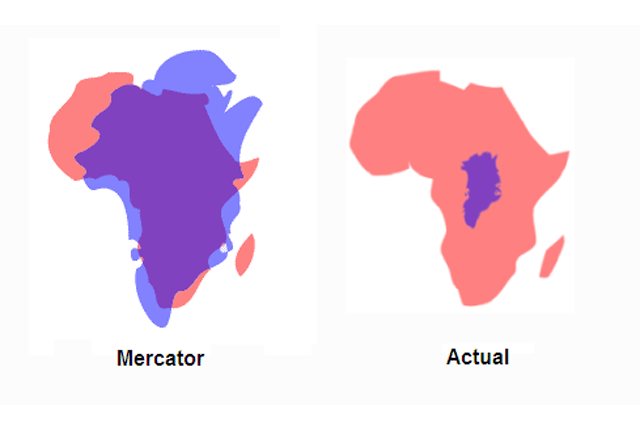

Avec R, on peut utiliser le package leaflet pour visualiser facilement OpenStreetMap.

```r
library(leaflet)
m <- leaflet() %>%
  addTiles() %>%  # Add default OpenStreetMap map tiles
  addMarkers(lng=174.768, lat=-36.852, popup="The birthplace of R")
m  # Print the map
```

[interactive chart not shown]

# 3 Distance du grand cercle

La distance à vol d’oiseau entre deux points se calcule avec la fonction suivante :

```r
dis <- function(long1, lat1, long2, lat2) {
  long1=long1*pi/180
  lat1=lat1*pi/180
  long2=long2*pi/180
  lat2=lat2*pi/180
  R <- 6371000
  delta.long <- (long2 - long1)
  delta.lat <- (lat2 - lat1)
  a <- sin(delta.lat/2)^2 + cos(lat1) * cos(lat2) * sin(delta.long/2)^2
  c <- 2 * asin(sqrt(a))
  d = R * c
  return(d)
}
```

On peut également exprimer les lat/lon d’un point final, à partir d’un point de départ, pour une distance et une direction donnée. Vous pourrez voir les routes orthodromique et loxodromique.

```r
# Direction, l'angle à partir du nord, en tournant à droite
t=pi/4
# Point de départ
phi1=48*pi/180;lambda1=0*pi/180
# Rayon de la Terre
R=6371000
# Distance
distance=seq(1,9000000,1200)

delta=distance/R
phi2 = asin( sin(phi1)*cos(delta) + cos(phi1)*sin(delta)*cos(t))
lambda2=lambda1 + atan2( sin(t)*sin(delta)*cos(phi1), cos(delta)-sin(phi1)*sin(phi2))


m=leaflet() %>%
  addTiles() %>%
  addPolygons(
    lng=lambda2*180/pi, lat=phi2*180/pi,fillColor = "transparent"
  )%>%
  addCircleMarkers(lng=lambda1*180/pi, lat=phi1*180/pi,radius=1,color="red")
m
```

[interactive chart not shown]

On peut ainsi faire la tour de la Terre.

```r
# Direction, l'angle à partir du nord, en tournant à droite
t=pi/4
# Point de départ
phi1=48*pi/180;lambda1=0*pi/180
# Rayon de la Terre
R=6371000
# Distance
distance=seq(1,2*pi*R,1200)

delta=distance/R
phi2 = asin( sin(phi1)*cos(delta) + cos(phi1)*sin(delta)*cos(t))
lambda2=lambda1 + atan2( sin(t)*sin(delta)*cos(phi1), cos(delta)-sin(phi1)*sin(phi2))


m=leaflet() %>%
  addTiles() %>%
  addPolygons(
    lng=lambda2*180/pi, lat=phi2*180/pi,fillColor = "transparent"
  )%>%
  addCircleMarkers(lng=lambda1*180/pi, lat=phi1*180/pi,radius=1,color="red")
m
```

[interactive chart not shown]

# 4 Cercle sur la Terre

La définition du cercle est assez intuitive sur une surface sphérique : étant donné un point, appelé le centre du cercle, l’ensemble des points à distance égale du centre forment un cercle.

Pour tracer le cercle, on suit ainsi cette définition.

```r
t=seq(0,2*pi,0.01)
phi1=0*pi/180;lambda1=0*pi/180
distance=9000000
R=6371000
delta=distance/R
phi2 = asin( sin(phi1)*cos(delta) + cos(phi1)*sin(delta)*cos(t))
lambda2=lambda1 + atan2( sin(t)*sin(delta)*cos(phi1), cos(delta)-sin(phi1)*sin(phi2))

m=leaflet() %>%
  addTiles() %>%
  addPolygons(
    lng=lambda2*180/pi, lat=phi2*180/pi,fillColor = "transparent"
  )%>%
  addCircleMarkers(lng=lambda1*180/pi, lat=phi1*180/pi,radius=1,color="red")
m
```

[interactive chart not shown]

# 5 Carré sur la Terre

On peut utiliser la définition suivante du carré sur une surface sphérique : un quadrilatère qui a quatre côté de même longueur. En revanche, les angles ne sont plus droits.

(D’ailleurs, ça me fait penser à une question, sur un triangle rectangle : étant donné un triangle rectangle, le côté opposé à l’angle rectangle a une longueur de 6, et la hauteur issue du sommet rectangle est de 5, quelle est l’aire du triangle ?)

Pour le tracer, il y a plusieurs façons, comme j’avais commencé le paramétrage angulaire, j’ai gardé ce paramétrage, en faisant varier la distance selon l’angle.

```r
t=seq(0,2*pi,0.001)
phi1=60*pi/180;lambda1=0*pi/180
pc=rep(c(1/cos(seq(0,pi/4,0.001)),rev(1/cos(seq(0,pi/4,0.001)))[-1]),4)
distance=1000000*pc
R=6371000
delta=distance/R
phi2 = asin( sin(phi1)*cos(delta) + cos(phi1)*sin(delta)*cos(t))
lambda2=lambda1 + atan2( sin(t)*sin(delta)*cos(phi1), cos(delta)-sin(phi1)*sin(phi2))


m=leaflet() %>%
  addTiles() %>%
  addPolygons(
    lng=lambda2*180/pi, lat=phi2*180/pi,fillColor = "transparent"
  )%>%
  addCircleMarkers(lng=lambda1*180/pi, lat=phi1*180/pi,radius=1,color="red")
m
```

[interactive chart not shown]

En variant les distances et le point central, on peut trouver des formes intéressantes :

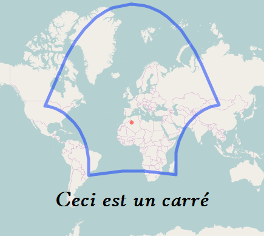

Un carré sur la Terre

# 6 Maillage

Comment on pourrait réaliser un maillage qui permet de découper la surface sphérique avec des aires égales ? Finalement, ce n’est pas une question si triviale. Si on est proche de l’équateur, on pourrait faire un maillage simple selon les latitude/longitude pour une surface pas trop grande. Si la surface est proche des pôles, et pas trop grande, on pourrait peut-être changer la base des coordonnées sphériques. Si on garde les coordonnées classiques, il faudrait décaler le quadriallage au fur et à mesure qu’on monte en latitude.

# 7 Références

- [Finding Points Within a Distance of a Latitude/Longitude Using Bounding Coordinates](http://janmatuschek.de/LatitudeLongitudeBoundingCoordinates)
- [Calculate distance, bearing and more between Latitude/Longitude points](http://www.movable-type.co.uk/scripts/latlong.html)
- [The Projection of Circles on a Mercator Map](http://articles.adsabs.harvard.edu//full/1932JRASC..26..161G/0000161.000.html)

Copyright © 2016 Blog de Kezhan Shi